# Supplementary Material for PENDING TITLE

# S7 - Testing the effect of combining density-dependent dispersal and reduced connectedness in simulations

[figure not shown]

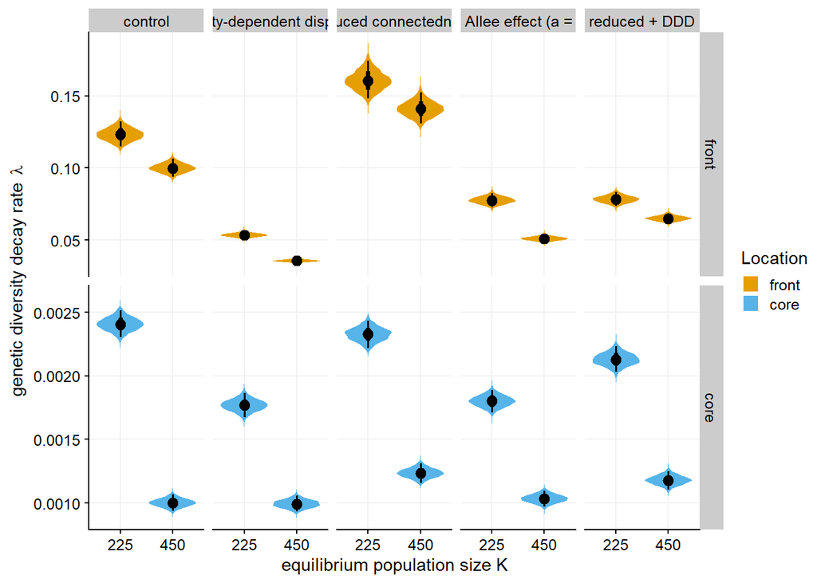

**Supplementary Figure S7.2** : Posterior distribution of the decay rate of genetic with time (*λ*) in simulations, depending on simulation scenario, equilibrium population size *K* and patch location (either the original release site (core) or the most advanced patch at the time of measure (front)). Please note that posterior for core and front patches are displayed on different scales on the y-axis, for readability.

# S8 - Differences in equilibrium population size between experimental treatments

We used a Beta generalized linear mixed model to determine whether *Trichogramma* population sizes (computer-estimated parasitism rates) differed between our two experimental treatments. We focused on core patches that were expected to be at equilibrium; for the purposes of this analysis, we conservatively defined “core” patches as “patches for which the distance to the release site is equal or lower than 25% of the distance release site – front patch at the time of sampling”. Our model included fixed effects of experimental treatment, as well as random effects of observation macro (to account for systematic macro bias, see **Supplementary Figure S2.1**), replicate identity, and patch identity nested in replicate and generation nested in patch to account for spatially and temporally repeated measures.

We found that equilibrium population sizes in the range core were higher when connectedness was restricted than in controls, with the average parasitism rate in the former being 121.16% [106.45; 137.58] of the average in the latter (**Supplementary Figure S8.1**).

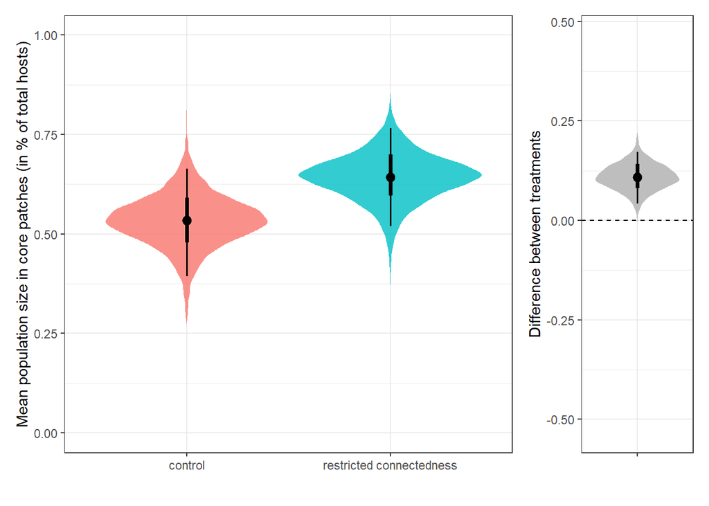

**Supplementary Figure S8.1** Left: Mean population size (estimated as host parasitism rate 7 days post-adult removal) as a function of treatment. Colored areas: posterior distribution; black dots and segment: posterior mean and 66/95% credible intervals. Right: posterior difference between the two experimental treatments.

# S9 - Model descriptions for models presented in Supplementary Materials

(As in S4, all Beta models described here use the (mean, precision) parametrisation of the Beta distribution.)

## S9.1 - validation of `CODICOUNT` estimates of population sizes (Supplementary Material S2)

To analyse for each available patch $i$ computer estimates of parasitism rate $P_{i,m}$ (where $m$ is the estimating computer macro) with human counts of parasitised eggs $n_{i}$, we used the following bivariate mixed model:

$$n_{i} \sim \mathrm{Binomial}(N = 450, p_{i}) \\
P_{i,m} \sim \mathrm{Beta}(\mu_{i}, \phi) \\
\mathrm{logit}(p_{i}) = \beta_{0} + \alpha_{i} \\
\mathrm{logit}(\mu_{i}) = \beta_{1} + \gamma_{i} \\$$

The patch-level random effects $\alpha$ and $\gamma$ are correlated and distributed as follow:

$$\begin{bmatrix}
\alpha_{i} \\
\gamma_{i} \\
\end{bmatrix} \sim
\mathrm{MVNormal}(
\begin{bmatrix}
0\\
0\\
\end{bmatrix},\boldsymbol{\Omega}) \\
\boldsymbol{\Omega} =
\begin{bmatrix}
\sigma_{\alpha} & 0 \\
0 & \sigma_{\gamma} \\
\end{bmatrix}
\times \boldsymbol{\mathrm{R}} \times
\begin{bmatrix}
\sigma_{\alpha} & 0 \\
0 & \sigma_{\gamma} \\
\end{bmatrix} \\$$
, where $\Omega$ and $\boldsymbol{\mathrm{R}}$ again refer the the covariance and correlation matrices, respectively. As in similar models described above, we use a $\mathrm{Normal}(0,1.5)$ forfixed effect ($\beta$) parameters, a $\mathrm{Half\mbox{-}Normal}(0,1)$ prior for standard deviations $\sigma$ and for $1/\phi$, and a $\mathrm{LKJCorr}(2)$ prior for the correlation matrix $\boldsymbol{\mathrm{R}}$.

We ran a second version of this model, to determine whether computer macros presented systematic estimation biases. In this case, the parameter $\beta_{1}$, which denotes the (logit-transformed) average parasitism rate in the “computer estimates” model, was simply changed to be macro-specific:
$$P_{i,m} \sim \mathrm{Beta}(\mu_{i,m}, \phi) \\
\mathrm{logit}(\mu_{i,m}) = \beta_{1[m]} + \gamma_{i}\\$$
, with the remaining of the model remaining unchanged.

## S9.2 - Validation of the experimental design (Supplementary Material S3)

We analysed the mean distance from release $\bar{D}_{i,m}$ between the eggs laid in a replicate $i$ (as seen from macro $m$) and the corresponding parental patch using data from the starting generation, when there were only 5 patches per replicate (including the release patch). This means $\bar{D}_{i,m}$ can only take values in the $\left]0, 4\right[$ range, and can be modelled as follow:

$$\frac{\bar{D}_{i,m}}{4} \sim \mathrm{Beta}(\mu_{i,m}, \phi) \\
\mathrm{logit}(\mu_{i,m})= \beta_{0[\text{TREATMENT}[i]} + \beta_{1} \times N_{i,m} + \alpha_{m}\\
\alpha_{m} \sim \mathrm{Normal}(0,\sigma_{\alpha}) \\$$
, where $N_{i,m}$ is the total proportion of eggs parasitised across the 5 patches of the replicate, centred and scaled to unit 1 SD. As in other Beta models, we used a $\mathrm{Normal}(0,1.5)$ prior for the treatment-specific intercepts $\beta_{0}$, a $\mathrm{Normal}(0,1)$ prior for $\beta_{1}$, and $\mathrm{Half\mbox{-}Normal}(0,1)$ priors for both the random effect standard deviation $\sigma_{\alpha}$ and $1/\phi$.

## S9.4 - Testing the effect of combining density-dependent dispersal and reduced connectedness in simulations (Supplementary Material S7)

See S4.2 and S4.3

## S9.5 - Differences in equilibrium population size between experimental treatments (Supplementary Material S8)

We assumed the parasitism rate $P_{i,x,t,m}$ observed by macro $m$ in patch $x$ of replicate $i$ after $t$ generations can be modelled as follow:

$$P_{i,x,t,m} \sim \mathrm{Beta}(\mu_{i,x,t,m}, \phi) \\
\mu_{i,x,t,m} = \beta_{\text{TREATMENT}[i]} +\alpha_{i} + \gamma_{i,x} + \zeta_{i,x,t} + \eta_{m}\\
\alpha_{i} \sim \mathrm{Normal}(0,\sigma_{\alpha}) \\
\gamma_{i,x} \sim \mathrm{Normal}(0,\sigma_{\gamma}) \\
\zeta_{i,x,t} \sim \mathrm{Normal}(0,\sigma_{\zeta}) \\
\eta_{m} \sim \mathrm{Normal}(0,\sigma_{\eta}) \\$$
, where $\alpha$ denote random effects of replicate, $\gamma$ of patch nested in replicate, $\zeta$ of time nested in patch and replicate, and $\eta$ random effects accounting for systematic between-macro differences. Priors were the same as in previous Beta models, that is a $\mathrm{Normal}(0,1.5)$ for $\beta$s, and a $\mathrm{Half\mbox{-}Normal}(0,1)$ for both random effect standard deviations $\sigma$ and for $1/\phi$.

# References

Abramoff, M. D., Paulo J. Magalhães, and Sunanda J. Ram. 2004. “Image Processing with ImageJ.” *Biophotonics International* 11 (7): 36–42.

Fellous, S., G. Angot, M. Orsucci, A. Migeon, P. Auger, I. Olivieri, and M. Navajas. 2014. “Combining Experimental Evolution and Field Population Assays to Study the Evolution of Host Range Breadth.” *Journal of Evolutionary Biology* 27 (5): 911–19. https://doi.org/10.1111/jeb.12362.

Gandhi, Saurabh R., Kirill S. Korolev, and Jeff Gore. 2019. “Cooperation Mitigates Diversity Loss in a Spatially Expanding Microbial Population.” *Proceedings of the National Academy of Sciences* 116 (47): 23582–7. https://doi.org/10.1073/pnas.1910075116.

McElreath, Richard. 2020. *Statistical Rethinking: A Bayesian Course with Examples in R and Stan*. 2nd edition. Boca Raton: Chapman and Hall/CRC.

Perez, Guy, Victor Burte, Olga Baron, and Vincent Calcagno. 2017. “Une méthode d’analyse d’image automatique pour quantifier rapidement les nombres d’œufs et les taux de parasitisme chez *Trichogramma* sp.” In *Innovations entomologiques : du laboratoire au champ !*, 135–42. Cahiers techniques de l’INRA.